# R Notebook - Airbnb Sevilla

# 1. Introducción y Objetivos

## 1.1. Contexto del Problema

El presente trabajo se centra en el análisis de datos del mercado de alquileres vacacionales en la ciudad de Sevilla, operado a través de la plataforma **Airbnb**.

**¿Por qué es interesante y cuál es su impacto actual?** El dominio de los alquileres turísticos es actualmente uno de los temas socioeconómicos más candentes a nivel local y nacional. Sevilla es uno de los principales focos turísticos de España, recibiendo a millones de visitantes anualmente. La irrupción de plataformas como Airbnb ha generado un volumen de negocio multimillonario, transformando por completo el mercado inmobiliario de la ciudad. Sin embargo, este fenómeno también ha traído consigo el debate sobre la turistificación, la gentrificación de barrios históricos y la subida del precio del alquiler residencial.

Entender este dominio mediante la Ciencia de Datos no solo es interesante desde una perspectiva de **inteligencia de negocio** (para inversores que buscan rentabilidad), sino también desde la **gestión pública** (para reguladores urbanísticos que necesitan comprender la saturación del Casco Antiguo).

## 1.2. Objetivos del Estudio

El objetivo principal de este proyecto es aplicar técnicas de *Machine Learning* y Análisis Exploratorio Avanzado para extraer *insights* de valor sobre la dinámica de precios y la profesionalización del sector. Para ello, planteamos tres preguntas de negocio fundamentales que cualquier inversor o analista se haría al estudiar este mercado. El dataset seleccionado es perfectamente representativo para responderlas, ya que contiene tanto la oferta de precios reales como la demanda latente (medida a través de las *reviews*).

Las preguntas a resolver son:

1. **Segmentación del mercado: ¿Podemos identificar clústeres de alojamientos que se comporten de forma distinta al estándar del barrio?**
   - *Utilidad real:* Permite a inversores identificar nichos de mercado (ej. “Tiburones inmobiliarios” de alta rotación frente a “Habitaciones compartidas de bajo coste”) y entender qué modelo de negocio domina cada zona de Sevilla, más allá de la media administrativa.
2. **Determinantes del Precio: ¿Qué variables determinan el precio de mercado en Sevilla y qué pisos están sobrevalorados?**
   - *Utilidad real:* Mediante modelos predictivos (Regresión), un inversor inmobiliario puede tasar objetivamente una vivienda basándose en sus características físicas (baños, capacidad) y detectar oportunidades de inversión (pisos infravalorados) frente a trampas de mercado (pisos con precio inflado sin justificación).
3. **El “Efecto Giralda”: ¿Cómo cae el precio del alquiler turístico por cada 100 metros que nos alejamos de la Catedral?**
   - *Utilidad real:* Convierte la geografía en matemáticas. Al cuantificar el decaimiento exacto del precio por metro de alejamiento, una agencia inmobiliaria puede calcular si el sobrecoste de comprar un piso en pleno centro se amortiza con la prima de facturación turística diaria.

## 1.3. Descripción del Dataset

Para abordar estas cuestiones, hemos utilizado un conjunto de datos público extraído del portal **Inside Airbnb**(https://insideairbnb.com/get-the-data/), un proyecto independiente que proporciona datos scrapeados directamente de la plataforma oficial para el análisis de su impacto en ciudades de todo el mundo.

- **Origen de los datos:** Archivo `listings.csv` correspondiente a la ciudad de Sevilla.
- **Volumen de observaciones (Filas):** El dataset original cuenta con **8.215 observaciones** (cada fila representa un alojamiento único ofertado en la ciudad).
- **Volumen de características (Columnas):** Contiene **79 variables** originales que detallan desde las coordenadas geográficas hasta las políticas de reserva y calificaciones de los huéspedes.
- **Tamaño del archivo:** El dataset en crudo ocupa aproximadamente **18.5 MB** de memoria física, lo que justifica la necesidad de aplicar técnicas de preprocesamiento, limpieza y reducción de dimensionalidad para optimizar el rendimiento computacional de nuestros algoritmos.

# 2. Selección de variables y preprocesamiento de datos

El dataset original de Airbnb (`listings.csv`) cuenta con **79 variables** y más de 8.000 observaciones. Gran parte de esta información consiste en metadatos técnicos (`scrape_id`), textos no estructurados (`description`, `urls`) o redundancias que introducen ruido en nuestro análisis.

Para abordar las tres preguntas de negocio planteadas (Segmentación por barrio, Predicción de Precio y Análisis Geoespacial), hemos ejecutado una **selección estratégica de características (Feature Selection)**. Hemos reducido la dimensionalidad del dataset a **20 variables clave**, agrupadas en cuatro dimensiones funcionales que explican la varianza del mercado:

#### **A. Dimensiones Estructurales (“El Hardware”)**

Variables necesarias para estandarizar la comparación entre alojamientos heterogéneos.

- **`room_type`**, **`accommodates`**, **`bedrooms`**: Definen la capacidad real y el modelo de alojamiento (privado vs. compartido). Son los predictores base del precio.
- **`bathrooms_text`**: Seleccionada para ingeniería de características. El número de baños es un indicador crítico de lujo/gama alta que a menudo se omite en análisis básicos.
- **`amenities`**: Aunque es texto, la transformaremos para cuantificar el “valor añadido” (piscina, aire acondicionado) que justifica sobreprecios.

#### **B. Dimensiones Económicas y de Gestión (“El Negocio”)**

Variables que permiten perfilar el comportamiento del anfitrión (Profesional vs. Particular).

- **`price`**: Variable objetivo principal. Requiere limpieza de caracteres (`$`, `,`) para su tratamiento numérico.
- **`availability_365`**: Proxy de dedicación. Distingue entre negocios de dedicación exclusiva y alquileres esporádicos.
- **`calculated_host_listings_count`** e **`instant_bookable`**: Métricas de profesionalización. Un anfitrión con múltiples propiedades y reserva inmediata tiene un perfil de riesgo y rotación distinto.

#### **C. Dimensiones de Reputación y Calidad (“El Valor Percibido”)**

Cruciales para el Clustering y para explicar outliers de precio.

- **`reviews_per_month`**: El mejor indicador de la demanda actual y la rotación del activo.
- **`review_scores_rating`**, **`_cleanliness`**, **`_location`**: Variables de calidad subjetiva. Permiten detectar alojamientos “sobrevalorados” (caros pero con mala nota) o “joyas ocultas”.

#### **D. Dimensiones Geoespaciales (“La Ubicación”)**

Necesarias para el análisis continuo del espacio urbano.

- **`latitude`** / **`longitude`**: Materia prima para el cálculo de distancia euclídea/haversine a la Giralda (Pregunta 3).
- **`neighbourhood_cleansed`**: Para establecer la línea base de precios por zona administrativa (Pregunta 2).

```r
library(tidyverse)
```

```r
library(corrplot)
listings <- read.csv("./csv/listings.csv")
```

```r
str(listings)
```

```
## 'data.frame':    8215 obs. of  79 variables:
##  $ id                                          : num  49287 108236 111140 159596 179629 ...
##  $ listing_url                                 : chr  "https://www.airbnb.com/rooms/49287" "https://www.airbnb.com/rooms/108236" "https://www.airbnb.com/rooms/111140" "https://www.airbnb.com/rooms/159596" ...
##  $ scrape_id                                   : num  2.03e+13 2.03e+13 2.03e+13 2.03e+13 2.03e+13 ...
##  $ last_scraped                                : chr  "2025-09-30" "2025-09-30" "2025-09-30" "2025-09-30" ...
##  $ source                                      : chr  "city scrape" "city scrape" "city scrape" "previous scrape" ...
##  $ name                                        : chr  "BEAUTIFUL APARTMENT IN SEVILLE" "Sunny apt in heart of seville!!" "Quiet&historicenter&local experienc" "apto lujo 2 D en el Arenal (Sevilla)" ...
##  $ description                                 : chr  "Nice apartment on the second floor of a beautiful house in the famous Alameda square in the old center of Sevil"| __truncated__ "Clean, quiet and cosy 2-bedroom apartment near Fine Arts Museum. Queen size beds, bathroom with a bathtub and s"|…
##  $ neighborhood_overview                       : chr  "The famous Plaza de Hercules has changed a lot since its restoration in 2004. Its a lively neighbourhood with m"| __truncated__ "The apartment is located in a prime, picturesque area of Old Seville, just a few minutes' walk from the Museo d"|…
##  $ picture_url                                 : chr  "https://a0.muscache.com/pictures/7a7b22d8-5f7f-4205-8d0b-1aaa690ae9b5.jpg" "https://a0.muscache.com/pictures/796657/67ae197e_original.jpg" "https://a0.muscache.com/pictures/797042/0cfbd568_original.jpg" "https://a0.muscache.com/pictures/2021d…
##  $ host_id                                     : int  224697 560040 560040 629861 860055 860055 1022533 1188880 1330663 1391956 ...
##  $ host_url                                    : chr  "https://www.airbnb.com/users/show/224697" "https://www.airbnb.com/users/show/560040" "https://www.airbnb.com/users/show/560040" "https://www.airbnb.com/users/show/629861" ...
##  $ host_name                                   : chr  "Walter" "José Luis" "José Luis" "Alvaro" ...
##  $ host_since                                  : chr  "2010-09-05" "2011-05-05" "2011-05-05" "2011-05-26" ...
##  $ host_location                               : chr  "Sevilla, Spain" "Seville, Spain" "Seville, Spain" "Sevilla, Spain" ...
```

[output cut: 65 more lines]

Antes de proceder al preprocesamiento, realizamos una inspección técnica del dataset crudo. De esta forma podemos analizar aspectos claves como:

- Duplicidad
- Missing values
- Consistencia

```r
# 1. ESTRUCTURA
print("--- Dimensiones del Dataset ---")
```

```
## [1] "--- Dimensiones del Dataset ---"
```

```r
dim(listings) # Filas x Columnas
```

```
## [1] 8215   79
```

```r
# 2. CHECK DE DUPLICADOS
duplicados_totales <- sum(duplicated(listings))
duplicados_id <- sum(duplicated(listings$id))

print(paste("Filas totalmente duplicadas:", duplicados_totales))
```

```
## [1] "Filas totalmente duplicadas: 0"
```

```r
print(paste("IDs repetidos (mismo piso scrapeado varias veces):", duplicados_id))
```

```
## [1] "IDs repetidos (mismo piso scrapeado varias veces): 0"
```

```r
# 3. MISSING VALUES
na_count <- colSums(is.na(listings))
na_percent <- (na_count / nrow(listings)) * 100

# Mostrar las 10 columnas con más nulos
print("--- Top 10 Columnas con más Nulos (%) ---")
```

```
## [1] "--- Top 10 Columnas con más Nulos (%) ---"
```

```r
print(sort(na_percent, decreasing = TRUE)[1:10])
```

```
##            calendar_updated        review_scores_rating
##                   100.00000                     8.82532
##      review_scores_accuracy   review_scores_cleanliness
##                     8.82532                     8.82532
##       review_scores_checkin review_scores_communication
##                     8.82532                     8.82532
##      review_scores_location         review_scores_value
##                     8.82532                     8.82532
##           reviews_per_month     estimated_revenue_l365d
##                     8.82532                     7.71759
```

```r
# 4. Variables clave Room Type y Precios
# Ver si hay categorías raras antes de limpiar
print("--- Categorías únicas en Room Type ---")
```

```
## [1] "--- Categorías únicas en Room Type ---"
```

```r
print(table(listings$room_type))
```

```
##
## Entire home/apt      Hotel room    Private room     Shared room
##            6993              21            1182              19
```

```r
# Ver formato del precio por si hay que limpiar
print("--- Ejemplo de Precios en crudo ---")
```

```
## [1] "--- Ejemplo de Precios en crudo ---"
```

```r
print(head(listings$price))
```

```
## [1] "$93.00"  "$120.00" "$89.00"  ""        "$146.00" ""
```

## 2.1. EDA inicial

En este punto hemos realizado un EDA pequeño, para hacernos una idea de donde partíamos, con qué tipo de datos tratamos, formato, valores nulos, incongruencias, en definitiva, qué sobra y qué nos parece interesante tratar y preprocesar en detalle.

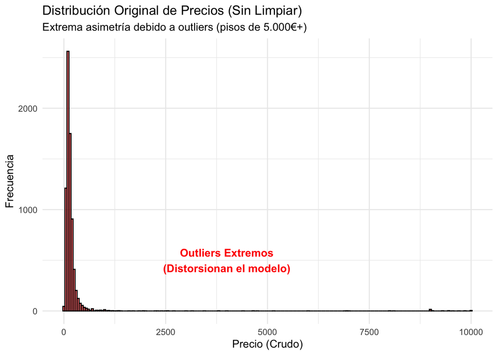

```r
library(ggplot2)
library(dplyr)

# GRÁFICO 1: EL "MONSTRUO" DE LOS PRECIOS
# Necesitamos convertir el precio a número "en sucio" solo para poder pintarlo
# (Sin modificar el dataset original todavía)
precios_sucios <- as.numeric(gsub("[\\$,]", "", listings$price))

# Creamos un dataframe temporal solo para este gráfico
df_plot_sucio <- data.frame(precio = precios_sucios)

ggplot(df_plot_sucio, aes(x = precio)) +
  geom_histogram(binwidth = 50, fill = "red", color = "black", alpha = 0.6) +
  theme_minimal() +
  labs(
    title = "Distribución Original de Precios (Sin Limpiar)",
    subtitle = "Extrema asimetría debido a outliers (pisos de 5.000€+)",
    x = "Precio (Crudo)",
    y = "Frecuencia"
  ) +
  annotate("text", x = 4000, y = 500, label = "Outliers Extremos\n(Distorsionan el modelo)", color = "red", fontface="bold")
```

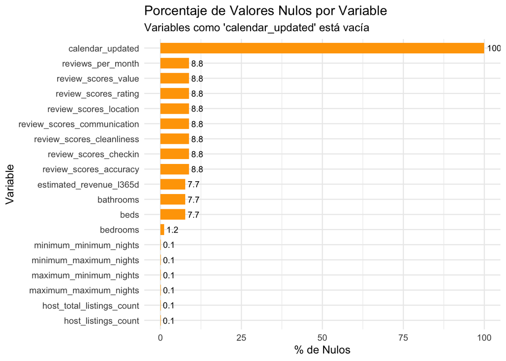

```r
# GRÁFICO 2: MAPA DE CALOR DE DATOS FALTANTES (NULOS)
# Calculamos el % de nulos por columna
na_summary <- data.frame(
  columna = names(listings),
  na_pct = colSums(is.na(listings)) / nrow(listings) * 100
) %>%
  filter(na_pct > 0) %>% # Solo mostramos las que tienen nulos
  arrange(desc(na_pct)) # Ordenamos de mayor a menor

# Pintamos solo las columnas problemáticas
ggplot(na_summary, aes(x = reorder(columna, na_pct), y = na_pct)) +
  geom_bar(stat = "identity", fill = "orange", width = 0.7) +
  coord_flip() + # Giramos para leer los nombres
  theme_minimal() +
  labs(
    title = "Porcentaje de Valores Nulos por Variable",
    subtitle = "Variables como 'calendar_updated' está vacía",
    x = "Variable",
    y = "% de Nulos"
  ) +
  geom_text(aes(label = round(na_pct, 1)), hjust = -0.2, size = 3)
```

Tras este pequeño análisis decidimos seleccionar las columnas que nos impactan. Así, podemos centrarnos en analizar profundamente solo las variables necesarias, y hacer el preprocesado detallado y centrado en nuestro caso concreto y no extendernos en algo que nos nos dará fruto para resolver nuestra hipótesis planteadas.

```r
# 1. SELECCIÓN DE COLUMNAS
df_raw_selected <- listings %>%
  select(
    # Identificador
    id,

    # Variables clave (Precios, Tipo y Estancia)
    price,
    room_type,
    accommodates,
    minimum_nights,

    # Variables estructurales
    bathrooms_text,
    bedrooms,
    amenities,

    # Ubicación
    neighbourhood_cleansed,
    neighbourhood_group_cleansed,
    latitude,
    longitude,

    # Actividad y reputación
    reviews_per_month,
    number_of_reviews,
    review_scores_rating,
    review_scores_cleanliness,
    review_scores_location,

    # Gestión
    availability_365,
    calculated_host_listings_count,
    instant_bookable
  )

print(paste("Columnas seleccionadas:", ncol(df_raw_selected)))
```

```
## [1] "Columnas seleccionadas: 20"
```

## 2.2. Preprocesado de Variables Críticas

```r
df_final <- df_raw_selected %>%

  # --- 1. LIMPIEZA DE PRECIO ---
  mutate(
    price_clean = as.numeric(gsub("[\\$,]", "", price))
  ) %>%
  # Filtrar precios coherentes
  filter(price_clean > 10 & price_clean < 1000) %>%

  # --- 2. LIMPIEZA DE BAÑOS (VERSIÓN MEJORADA) ---
  mutate(
    # 2.1. Sacamos el NÚMERO (Cantidad)
    bathrooms_qty = as.numeric(str_extract(bathrooms_text, "\\d+(\\.\\d+)?")),
    bathrooms_qty = ifelse(is.na(bathrooms_qty) & str_detect(bathrooms_text, "Half-bath"), 0.5, bathrooms_qty),
    bathrooms_qty = ifelse(is.na(bathrooms_qty), 1, bathrooms_qty),

    # 2.2. Sacamos la PRIVACIDAD (Calidad)
    # Si detecta "shared", pone un 1. Si no, un 0.
    bath_shared = ifelse(str_detect(bathrooms_text, regex("shared", ignore_case = TRUE)), 1, 0)
  ) %>%

  # --- 3. INGENIERÍA DE AMENITIES ---
  mutate(
    amenities_count = str_count(amenities, ",") + 1,
    amenities_count = ifelse(is.na(amenities) | amenities == "" | amenities == "[]", 0, amenities_count),
    has_pool = as.integer(str_detect(amenities, regex("pool", ignore_case = TRUE))),
    has_ac = as.integer(str_detect(amenities, regex("air conditioning|ac", ignore_case = TRUE)))
  ) %>%

  # --- 4. TRATAMIENTO DE NULOS ---
  group_by(room_type)%>%
    mutate(
      reviews_per_month = replace_na(reviews_per_month, 0),
      bedrooms = ifelse(is.na(bedrooms), median(bedrooms, na.rm = TRUE), bedrooms),
      review_scores_rating = ifelse(is.na(review_scores_rating), mean(review_scores_rating, na.rm = TRUE), review_scores_rating),
      review_scores_cleanliness = ifelse(is.na(review_scores_cleanliness), mean(review_scores_cleanliness, na.rm = TRUE), review_scores_cleanliness),
      review_scores_location = ifelse(is.na(review_scores_location), mean(review_scores_location, na.rm = TRUE), review_scores_location),
      instant_bookable_binary = ifelse(instant_bookable == "t", 1, 0),

      # LIMPIEZA DE MINIMUM_NIGHTS
      minimum_nights = ifelse(is.na(minimum_nights), 1, minimum_nights)
    ) %>%
  ungroup() %>%
  # --- 5. SELECCIÓN FINAL ---
  select(
    id,
    price = price_clean,
    room_type,
    accommodates,
    minimum_nights,
    bedrooms,
    bathrooms = bathrooms_qty,
    bath_shared,
    amenities_count, has_pool, has_ac,
    neighbourhood_cleansed,
    neighbourhood_group_cleansed,
    latitude, longitude,
    reviews_per_month, number_of_reviews,
    review_scores_rating, review_scores_cleanliness, review_scores_location,
    availability_365, calculated_host_listings_count,
    instant_bookable = instant_bookable_binary
  ) %>%

  # --- 6. CONVERSIÓN A FACTORES ---
  # Convertimos texto y binarios a categorías para que R los entienda bien en los gráficos
  mutate(
    room_type = as.factor(room_type),
    neighbourhood_cleansed = as.factor(neighbourhood_cleansed)
  )

# Verificar estructura final
glimpse(df_final)
```

```
## Rows: 7,484
## Columns: 23
## $ id                             <dbl> 49287, 108236, 111140, 179629, 207702, …
## $ price                          <dbl> 93, 120, 89, 146, 85, 54, 80, 105, 127,…
## $ room_type                      <fct> Entire home/apt, Entire home/apt, Entir…
## $ accommodates                   <int> 3, 5, 4, 5, 2, 1, 2, 6, 2, 1, 4, 2, 4, …
## $ minimum_nights                 <int> 3, 2, 2, 3, 3, 1, 3, 2, 2, 3, 1, 3, 2, …
## $ bedrooms                       <dbl> 1, 2, 1, 3, 1, 1, 1, 2, 1, 1, 2, 1, 2, …
## $ bathrooms                      <dbl> 1.0, 1.0, 1.0, 1.0, 1.0, 1.5, 1.0, 1.0,…
## $ bath_shared                    <dbl> 0, 0, 0, 0, 0, 1, 0, 0, 0, 1, 0, 0, 0, …
## $ amenities_count                <dbl> 50, 63, 53, 29, 37, 25, 35, 28, 51, 39,…
## $ has_pool                       <int> 0, 1, 0, 0, 0, 0, 0, 0, 0, 0, 0, 0, 0, …
## $ has_ac                         <int> 1, 1, 1, 1, 1, 1, 1, 1, 1, 1, 1, 1, 1, …
## $ neighbourhood_cleansed         <fct> "San Lorenzo", "San Vicente", "San Vice…
## $ neighbourhood_group_cleansed   <chr> "Casco Antiguo", "Casco Antiguo", "Casc…
## $ latitude                       <dbl> 37.39898, 37.39686, 37.39592, 37.38731,…
## $ longitude                      <dbl> -5.995330, -5.999127, -5.999317, -5.990…
## $ reviews_per_month              <dbl> 0.23, 1.27, 0.36, 1.23, 3.78, 1.41, 1.9…
## $ number_of_reviews              <int> 40, 222, 63, 205, 508, 238, 331, 459, 6…
## $ review_scores_rating           <dbl> 4.64, 4.77, 4.70, 4.55, 4.87, 4.94, 4.7…
## $ review_scores_cleanliness      <dbl> 4.97, 4.81, 4.69, 4.77, 4.95, 4.96, 4.6…
## $ review_scores_location         <dbl> 4.92, 4.86, 4.82, 4.93, 4.94, 4.91, 4.9…
## $ availability_365               <int> 206, 79, 106, 245, 111, 62, 148, 32, 12…
## $ calculated_host_listings_count <int> 1, 4, 4, 24, 1, 2, 2, 5, 205, 2, 1, 1, …
## $ instant_bookable               <dbl> 1, 0, 0, 1, 0, 0, 0, 1, 1, 0, 0, 1, 1, …
```

```r
summary(df_final$minimum_nights)
```

```
##    Min. 1st Qu.  Median    Mean 3rd Qu.    Max.
##    1.00    1.00    2.00    2.96    2.00  360.00
```

Para garantizar la robustez de los modelos posteriores (Clustering y Regresión), hemos implementado una transformación sobre el dataset original (`df_raw_selected`). Las operaciones realizadas son las siguientes:

**1. Limpieza y Filtrado de la Variable Objetivo (`Price`)** La variable precio original contenía caracteres no numéricos (`$` y `,`). Se ha convertido a tipo numérico y posterior filtrado.

- **Decisión:** Se han eliminado registros con precios inferiores a **10€** (errores de carga o precios ínfimos) y superiores a **1.000€** (outliers extremos/mansiones).  
  Esto reduce la asimetría de la distribución y evita que los valores extremos distorsionen la media y los centroides en el análisis de K-Means.

**2. Extracción de Información Estructural (`Bathrooms`)** La columna `bathrooms_text` presentaba información no estructurada (ej. *“1.5 baths”*). Hemos realizado las siguientes acciones:

- Extraído el valor numérico.
- Hemos imputado el valor **0.5** para los casos etiquetados como *“Half-bath”*.
- Hemos asumido un valor estándar de **1** baño para los valores nulos restantes.

**3. Características de Servicios (`Amenities`)** La columna `amenities` es una lista de texto JSON compleja, muy interesante porque podemos recoger qué características “deluxe” tienen los pisos. Para ello, hemos creado tres nuevas variables sintéticas y asi cuantificar el valor añadido:

- **`amenities_count`**: Conteo del número total de servicios ofrecidos, como indicador general del nivel de equipamiento.
- **`has_pool`** y **`has_ac`**: Variables binarias (1/0) creadas mediante búsqueda de patrones de texto. Consideramos que en un sitio como Sevilla, la piscina y el aire acondicionado son críticos para el precio (Pregunta 2).

```r
head(df_final)
```

| id | price | room_type | accommodates | minimum_nights | bedrooms | bathrooms | bath_shared | amenities_count | has_pool | has_ac | neighbourhood_cleansed | neighbourhood_group_cleansed | latitude | longitude | reviews_per_month | number_of_reviews | review_scores_rating | review_scores_cleanliness | review_scores_location | availability_365 | calculated_host_listings_count | instant_bookable |
| --- | --- | --- | --- | --- | --- | --- | --- | --- | --- | --- | --- | --- | --- | --- | --- | --- | --- | --- | --- | --- | --- | --- |
| 49287 | 93 | Entire home/apt | 3 | 3 | 1 | 1.0 | 0 | 50 | 0 | 1 | San Lorenzo | Casco Antiguo | 37.39898 | -5.995330 | 0.23 | 40 | 4.64 | 4.97 | 4.92 | 206 | 1 | 1 |
| 108236 | 120 | Entire home/apt | 5 | 2 | 2 | 1.0 | 0 | 63 | 1 | 1 | San Vicente | Casco Antiguo | 37.39686 | -5.999127 | 1.27 | 222 | 4.77 | 4.81 | 4.86 | 79 | 4 | 0 |
| 111140 | 89 | Entire home/apt | 4 | 2 | 1 | 1.0 | 0 | 53 | 0 | 1 | San Vicente | Casco Antiguo | 37.39592 | -5.999317 | 0.36 | 63 | 4.70 | 4.69 | 4.82 | 106 | 4 | 0 |
| 179629 | 146 | Entire home/apt | 5 | 3 | 3 | 1.0 | 0 | 29 | 0 | 1 | Santa Cruz | Casco Antiguo | 37.38731 | -5.990950 | 1.23 | 205 | 4.55 | 4.77 | 4.93 | 245 | 24 | 1 |
| 207702 | 85 | Entire home/apt | 2 | 3 | 1 | 1.0 | 0 | 37 | 0 | 1 | Museo | Casco Antiguo | 37.38945 | -5.998890 | 3.78 | 508 | 4.87 | 4.95 | 4.94 | 111 | 1 | 0 |
| 227905 | 54 | Private room | 1 | 1 | 1 | 1.5 | 1 | 25 | 0 | 1 | Museo | Casco Antiguo | 37.39299 | -5.999160 | 1.41 | 238 | 4.94 | 4.96 | 4.91 | 62 | 2 | 0 |

```r
# Asumiendo que ya cargaste library(tidyverse) o library(readr)
write_csv(df_final, file = "./csv/listings_preprocesado.csv")
```

## 2.3. Filtrado de Inconsistencias

```r
# --- 2.3. FILTRADO DE INCONSISTENCIAS Y OUTLIERS ---
# Partimos de df_final que ya tiene las variables limpias (baños, amenities, etc.)

df_eda <- df_final %>%
  # A. Filtro de Precio: Ajustamos a tu rango (10€ - 1.000€)
  filter(price > 10 & price < 1000) %>%

  # B. Filtro Geoespacial: Seguridad por si falló algo
  filter(!is.na(latitude) & !is.na(longitude)) %>%

  # C. Filtro de Estancias: Eliminamos alquileres de año completo (posibles errores)
  filter(minimum_nights < 365)

# Ver cuántas filas nos quedan vs las originales
print(paste("Observaciones originales:", nrow(df_final)))
```

```
## [1] "Observaciones originales: 7484"
```

```r
print(paste("Observaciones para análisis (df_eda):", nrow(df_eda)))
```

```
## [1] "Observaciones para análisis (df_eda): 7484"
```

# 3. Análisis Exploratorio de Datos

## 3.1. Análisis Univariante

### 3.1.1 Distribución del precio

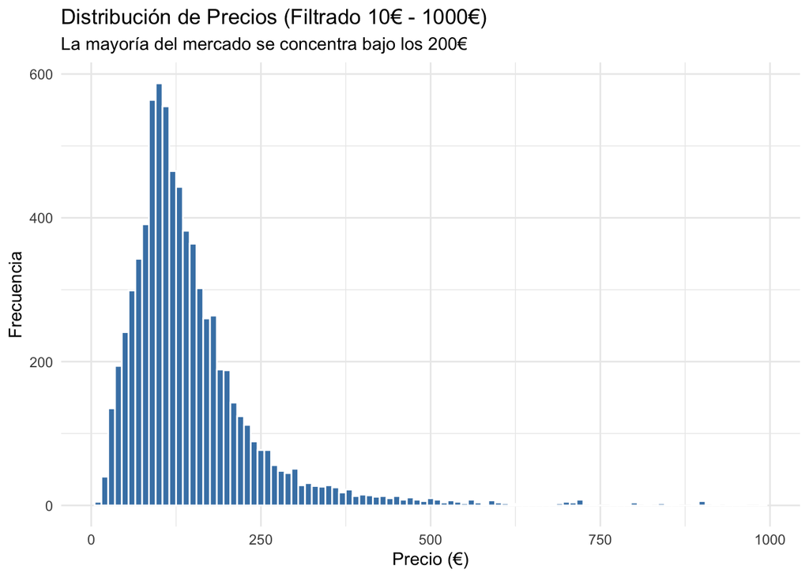

```r
# 3.1.1 Distribución del Precio
ggplot(df_eda, aes(x = price)) +
  geom_histogram(binwidth = 10, fill = "steelblue", color = "white") +
  theme_minimal() +
  labs(title = "Distribución de Precios (Filtrado 10€ - 1000€)",
       subtitle = "La mayoría del mercado se concentra bajo los 200€",
       x = "Precio (€)", y = "Frecuencia")
```

### 3.1.2 Conteo del tipo de habitacion

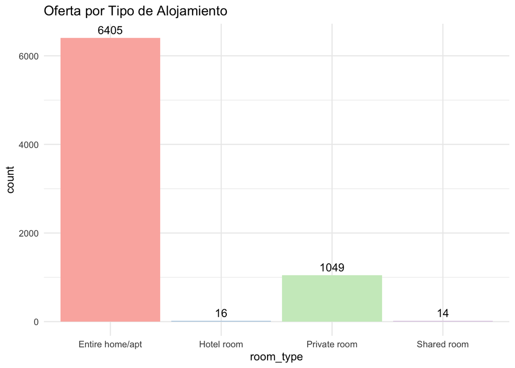

```r
# 3.1.2 Conteo por Tipo de Habitación
ggplot(df_eda, aes(x = room_type, fill = room_type)) +
  geom_bar() +
  geom_text(stat='count', aes(label=..count..), vjust=-0.5) +
  theme_minimal() +
  scale_fill_brewer(palette = "Pastel1") +
  labs(title = "Oferta por Tipo de Alojamiento") +
  theme(legend.position = "none")
```

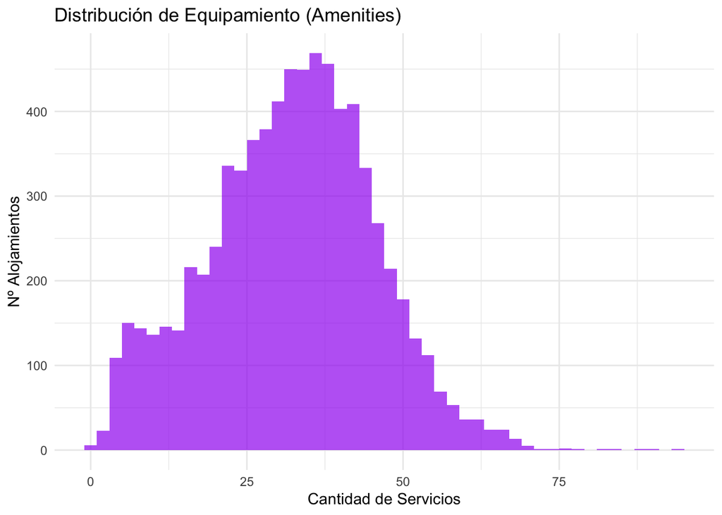

```r
# 3.1.3 Distribución de Servicios (Amenities Count)
# Importante para justificar que hay pisos "pelados" y pisos "equipados"
ggplot(df_eda, aes(x = amenities_count)) +
  geom_histogram(binwidth = 2, fill = "purple", alpha = 0.7) +
  theme_minimal() +
  labs(title = "Distribución de Equipamiento (Amenities)",
       x = "Cantidad de Servicios", y = "Nº Alojamientos")
```

### 3.1.4 Validación de Normalidad del Precio

¿Por qué este gráfico? Siguiendo el Tema 5 (Análisis Univariante), usamos el QQ-Plot para comprobar si la variable objetivo (price) sigue una distribución normal. La desviación de los puntos respecto a la línea diagonal nos confirmará visualmente la fuerte asimetría positiva de los precios, justificando así posibles transformaciones (como aplicar logaritmos) antes de entrenar nuestros modelos de Regresión.

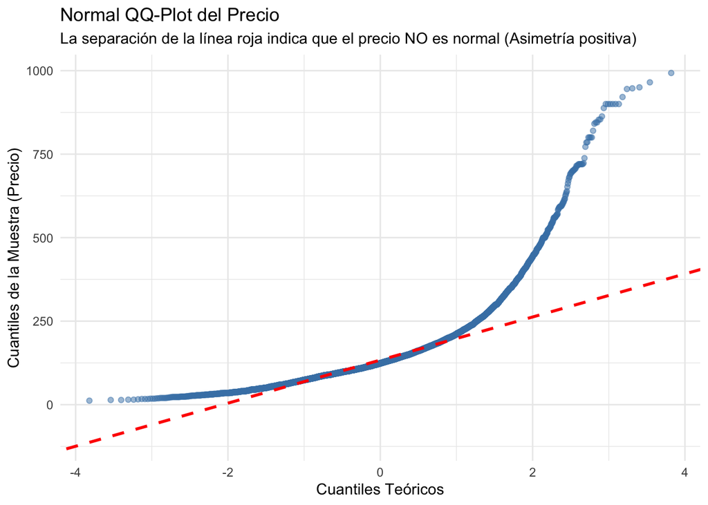

```r
# 3.1.4Normal QQ-Plot (Validación de Normalidad del Precio)
ggplot(df_eda, aes(sample = price)) +
  stat_qq(color = "steelblue", alpha = 0.5) +
  stat_qq_line(color = "red", linetype = "dashed", size = 1) +
  theme_minimal() +
  labs(title = "Normal QQ-Plot del Precio",
       subtitle = "La separación de la línea roja indica que el precio NO es normal (Asimetría positiva)",
       x = "Cuantiles Teóricos",
       y = "Cuantiles de la Muestra (Precio)")
```

## 3.2. Análisis Bivariante

### 3.2.1 Matriz de Correlación

Aquí detectamos la Multicolinealidad

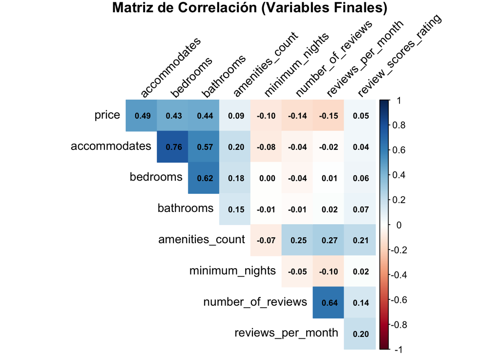

```r
# 3.2.1 Matriz de Correlación (Usando las nuevas variables numéricas)
library(corrplot)

# Seleccionamos las numéricas clave del nuevo dataset
nums <- df_eda %>%
  select(price, accommodates, bedrooms, bathrooms, # Tu variable limpia
         amenities_count, minimum_nights,          # Tus variables nuevas
         number_of_reviews, reviews_per_month,
         review_scores_rating) %>%
  na.omit()

M <- cor(nums)

corrplot(M, method = "color", type = "upper",
         addCoef.col = "black", number.cex = 0.7, # Tamaño letra números
         tl.col = "black", tl.srt = 45,
         diag = FALSE,
         title = "Matriz de Correlación (Variables Finales)",
         mar = c(0,0,1,0)) # Ajuste de margen para el título
```

### 3.2.2 Impacto del Baño Compartido

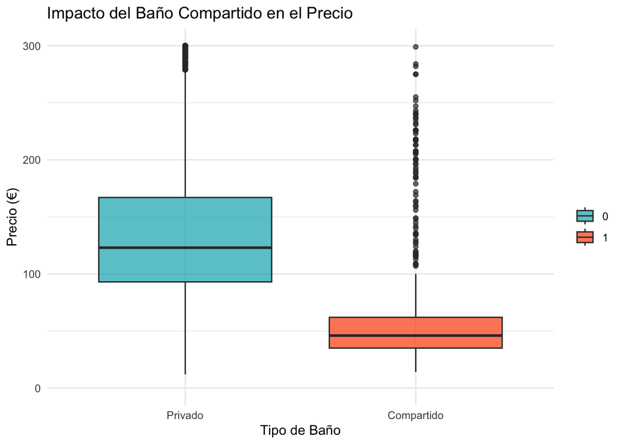

```r
# 3.2.2 Impacto del Baño Compartido
# Esto valida visualmente si 'bath_shared' afecta al precio
ggplot(df_eda, aes(x = as.factor(bath_shared), y = price, fill = as.factor(bath_shared))) +
  geom_boxplot(alpha = 0.7) +
  scale_x_discrete(labels = c("0" = "Privado", "1" = "Compartido")) +
  scale_fill_manual(values = c("#00AFBB", "#FC4E07")) +
  theme_minimal() +
  ylim(0, 300) + # Zoom para ver mejor las cajas (ignorando mansiones)
  labs(title = "Impacto del Baño Compartido en el Precio",
       x = "Tipo de Baño", y = "Precio (€)", fill = "")
```

### 3.2.3 Scatterplot Price vs Reviews

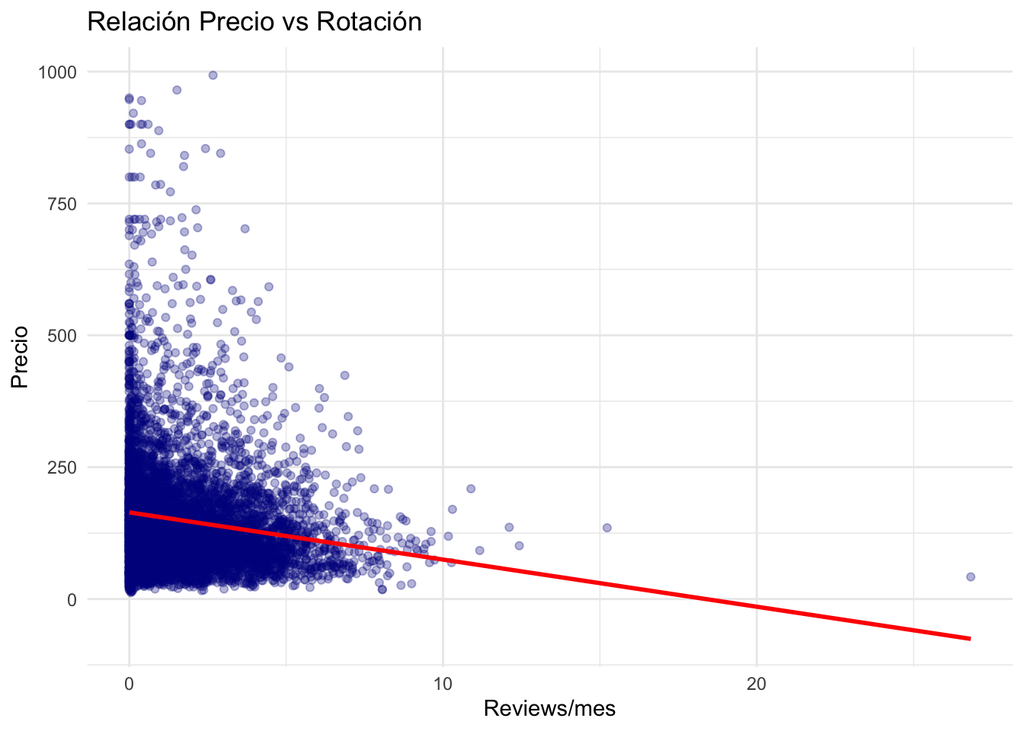

```r
# 3.2.3 Precio vs Reviews (Rotación)
ggplot(df_eda, aes(x = reviews_per_month, y = price)) +
  geom_point(alpha = 0.3, color = "darkblue") +
  geom_smooth(method = "lm", color = "red", se = FALSE) +
  theme_minimal() +
  labs(title = "Relación Precio vs Rotación", x = "Reviews/mes", y = "Precio")
```

### 3.2.4 Gráfico Multivariante: Boxplot Paralelo (Categórica + Cuantitativa)

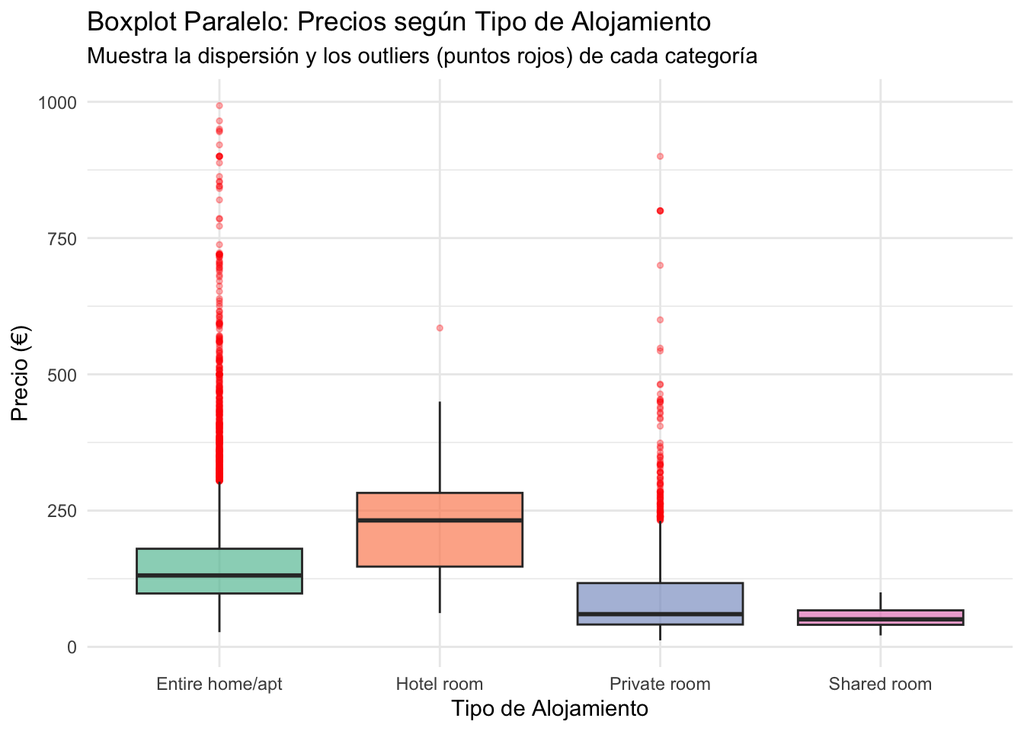

```r
# 3.2.4 Boxplot Paralelo: Precio vs Tipo de Alojamiento
ggplot(df_eda, aes(x = room_type, y = price, fill = room_type)) +
  geom_boxplot(alpha = 0.7, outlier.color = "red", outlier.size = 1, outlier.alpha = 0.3) +
  theme_minimal() +
  scale_fill_brewer(palette = "Set2") +
  labs(title = "Boxplot Paralelo: Precios según Tipo de Alojamiento",
       subtitle = "Muestra la dispersión y los outliers (puntos rojos) de cada categoría",
       x = "Tipo de Alojamiento",
       y = "Precio (€)") +
  theme(legend.position = "none")
```